# R Notebook

# Libraries

```r
library(tidyverse)
library(GGally)
library(ggfortify)
library(fastDummies)
```

# 1) Load the housing_prices.csv data set and undertake an initial exploration of the data.

```r
housing_prices <- read_csv("data/housing_prices.csv")
```

```r
housing_prices %>% head()
```

| longitude | latitude | housing_median_age | total_rooms | total_bedrooms | population | households | median_income | median_house_value | ocean_proximity |
| --- | --- | --- | --- | --- | --- | --- | --- | --- | --- |
| -122.23 | 37.88 | 41 | 880 | 129 | 322 | 126 | 8.3252 | 452600 | NEAR BAY |
| -122.22 | 37.86 | 21 | 7099 | 1106 | 2401 | 1138 | 8.3014 | 358500 | NEAR BAY |
| -122.24 | 37.85 | 52 | 1467 | 190 | 496 | 177 | 7.2574 | 352100 | NEAR BAY |
| -122.25 | 37.85 | 52 | 1274 | 235 | 558 | 219 | 5.6431 | 341300 | NEAR BAY |
| -122.25 | 37.85 | 52 | 1627 | 280 | 565 | 259 | 3.8462 | 342200 | NEAR BAY |
| -122.25 | 37.85 | 52 | 919 | 213 | 413 | 193 | 4.0368 | 269700 | NEAR BAY |

```r
housing_prices %>% summary()
```

```
   longitude         latitude     housing_median_age  total_rooms    total_bedrooms     population      households
 Min.   :-124.3   Min.   :32.54   Min.   : 1.00      Min.   :    2   Min.   :   2.0   Min.   :    3   Min.   :   2.0
 1st Qu.:-121.8   1st Qu.:33.93   1st Qu.:18.00      1st Qu.: 1438   1st Qu.: 297.0   1st Qu.:  796   1st Qu.: 282.0
 Median :-118.5   Median :34.27   Median :28.00      Median : 2111   Median : 436.0   Median : 1179   Median : 411.0
 Mean   :-119.6   Mean   :35.65   Mean   :28.39      Mean   : 2620   Mean   : 539.6   Mean   : 1441   Mean   : 501.2
 3rd Qu.:-118.0   3rd Qu.:37.73   3rd Qu.:37.00      3rd Qu.: 3120   3rd Qu.: 648.0   3rd Qu.: 1746   3rd Qu.: 606.0
 Max.   :-114.3   Max.   :41.95   Max.   :52.00      Max.   :39320   Max.   :6445.0   Max.   :35682   Max.   :6082.0
                                                                     NA's   :200
 median_income     median_house_value ocean_proximity
 Min.   : 0.4999   Min.   : 14999     Length:19675
 1st Qu.: 2.5268   1st Qu.:116600     Class :character
 Median : 3.4500   Median :173800     Mode  :character
 Mean   : 3.6767   Mean   :192478
 3rd Qu.: 4.5826   3rd Qu.:248200
 Max.   :15.0001   Max.   :500000
```

## Feature engineering

```r
housing_features %>%
  select(rooms_per_house:prop_bedrooms) %>%
  skimr::skim()
```

```
-- Data Summary ------------------------
                           Values
Name                       Piped data
Number of rows             19675
Number of columns          6
_______________________
Column type frequency:
  numeric                  6
________________________
Group variables            None
```

|  | skim_variable | n_missing | complete_rate | mean | sd | p0 | p25 | p50 | p75 | p100 | hist |
| --- | --- | --- | --- | --- | --- | --- | --- | --- | --- | --- | --- |
| 1 | rooms_per_house | 0 | 1.0000000 | 5.3609011 | 2.29253818 | 0.8461538462 | 4.4145675 | 5.1843220 | 5.9706767 | 132.533333 |  |
| 2 | bedrooms_per_house | 200 | 0.9898348 | 1.0970175 | 0.45393339 | 0.3333333333 | 1.0058881 | 1.0487805 | 1.0994620 | 34.066667 |  |
| 3 | rooms_per_person | 0 | 1.0000000 | 1.9393782 | 1.10014418 | 0.0025469169 | 1.4991141 | 1.9117148 | 2.2492904 | 55.222222 |  |
| 4 | bedrooms_per_person | 200 | 0.9898348 | 0.4003404 | 0.23841768 | 0.0006702413 | 0.3135992 | 0.3699187 | 0.4403794 | 14.194444 |  |
| 5 | houses_per_person | 0 | 1.0000000 | 0.3614741 | 0.09196174 | 0.0008042895 | 0.3025816 | 0.3524684 | 0.4089167 | 1.444444 |  |
| 6 | prop_bedrooms | 200 | 0.9898348 | 0.2149754 | 0.05693687 | 0.1000000000 | 0.1776552 | 0.2045827 | 0.2409499 | 1.000000 |  |

# 2) We expect the total_rooms of houses to be strongly correlated with total_bedrooms. Use ggpairs() to investigate correlations between these two variables.

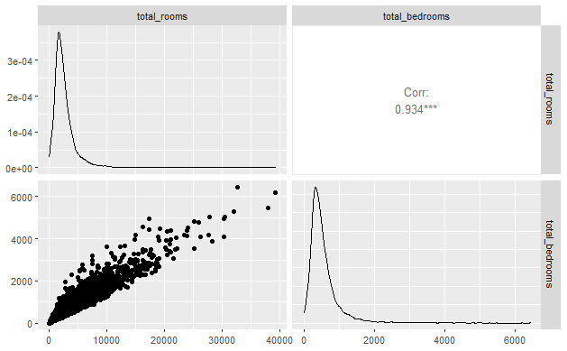

The correlation between the two variables is very strong at 0.934.

# 3) So, we do find significant correlations. Let’s drop total_bedrooms from the dataset, and use only total_rooms going forward.

```r
housing_prices <- housing_prices %>%
  select(-total_bedrooms)
```

# 4) We are interested in developing a regression model for the median_house_value of a house in terms of the possible predictor variables in the dataset.

## 4.1) Use ggpairs() to investigate correlations between median_house_value and the predictors (this may take a while to run, don’t worry, make coffee or something).

[figure not shown]

```r
ggpairs(housing_prices, progress = FALSE)
```

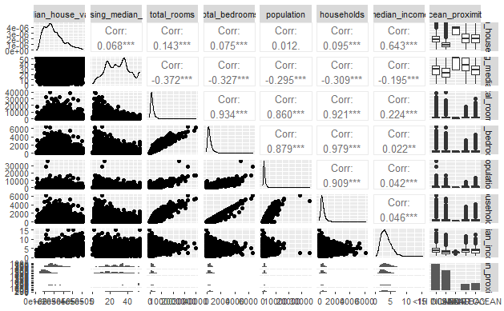

```r
housing_features %>%
  select(-c(longitude, latitude,
            rooms_per_house:prop_bedrooms)) %>%
  select(median_house_value, everything()) %>% #rearranging order so variable of interest is at the beginning
  ggpairs(progress = FALSE)
```

```r
NA
NA
```

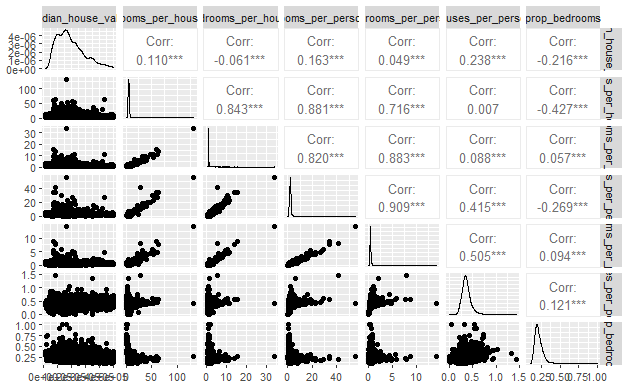

```r
housing_features %>%
  select(median_house_value, rooms_per_house:prop_bedrooms) %>%
  #select(median_house_value, everything()) %>% #rearranging order so variable of interest is at the beginning
  ggpairs(progress = FALSE)
```

### Observations:

-median income - very promising, high corrlation -ocean proximity: want to explore levels, 2snd level seems different to rest, can we group? -houses/person, prop_bedrooms, rooms/house - potentially useful

### Further feature engineering for ocean proximity

| ocean_proximity | n |
| --- | --- |
| <1H OCEAN | 8604 |
| INLAND | 6524 |
| ISLAND | 5 |
| NEAR BAY | 2096 |
| NEAR OCEAN | 2446 |

can we group this? YES! Second level which had lower distribution of median price, is different, all the others are near water.

```r
# group into two category variable
housing_features <- housing_features %>%
  mutate(ocean_prox_group = if_else(ocean_proximity == "INLAND",
                                    "Inland",
                                    "Near Water"))

housing_features %>%
  count(ocean_prox_group)
```

| ocean_prox_group | n |
| --- | --- |
| Inland | 6524 |
| Near Water | 13151 |

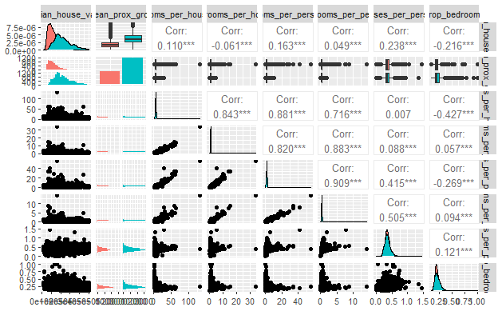

```r
housing_features %>%
  select(median_house_value, ocean_prox_group, rooms_per_house:prop_bedrooms) %>%
  #select(median_house_value, everything()) %>% #rearranging order so variable of interest is at the beginning
  ggpairs(aes(fill = ocean_prox_group),progress = FALSE)
```

## 4.2) Perform further ggplot visualisations of any significant correlations you find.

| cor(latitude, median_house_value) |
| --- |
| -0.1482893 |

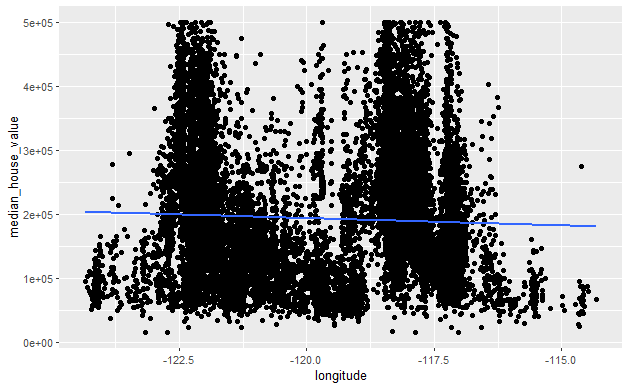

```r
#longitude and median house value
housing_prices %>%
  ggplot(aes(x = longitude,
             y = median_house_value)) +
  geom_point()+
  geom_smooth(method = "lm", se = FALSE)
```

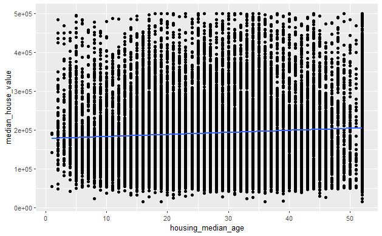

```r
#housing_median_age and median house value
housing_prices %>%
  ggplot(aes(x = housing_median_age,
             y = median_house_value)) +
  geom_point()+
  geom_smooth(method = "lm", se = FALSE)
```

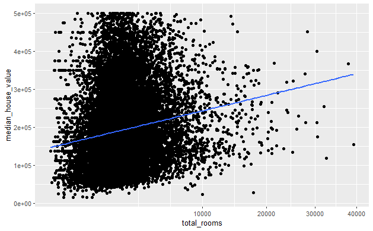

```r
#total rooms and median house value
housing_prices %>%
  ggplot(aes(x = total_rooms,
             y = median_house_value)) +
  geom_point()+
  scale_x_sqrt()+
  geom_smooth(method = "lm", se = FALSE)
```

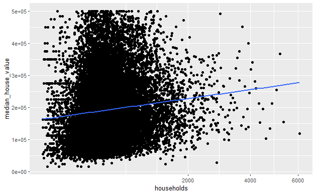

```r
#households and median house value
housing_prices %>%
  ggplot(aes(x = households,
             y = median_house_value)) +
  geom_point()+
  scale_x_sqrt() +
  geom_smooth(method = "lm", se = FALSE)
```

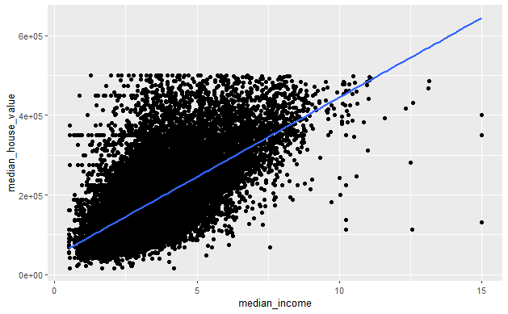

```r
#median_income and median house value
housing_prices %>%
  ggplot(aes(x = median_income,
             y = median_house_value)) +
  geom_point()+
  geom_smooth(method = "lm", se = FALSE)
```

# 5) Shortly we may try a regression model to fit the categorical predictor ocean_proximity. Investigate the level of ocean_proximity predictors. How many dummy variables do you expect to get from it?

I expect to get 4 dummy variables (n - 1)

```r
housing_prices %>%
  group_by(ocean_proximity) %>%
  summarise(number = n())
```

| ocean_proximity | number |
| --- | --- |
| <1H OCEAN | 8604 |
| INLAND | 6524 |
| ISLAND | 5 |
| NEAR BAY | 2096 |
| NEAR OCEAN | 2446 |

# 6) Start with simple linear regression. Regress median_house_value on median_income and check the regression diagnostics.

```r
summary(model_income_value)
```

```
Call:
lm(formula = median_house_value ~ median_income, data = housing_prices)

Residuals:
    Min      1Q  Median      3Q     Max
-513966  -51564  -13979   36549  403935

Coefficients:
              Estimate Std. Error t value Pr(>|t|)
(Intercept)    45457.0     1359.0   33.45   <2e-16 ***
median_income  39987.0      339.9  117.64   <2e-16 ***
---
Signif. codes:  0 ‘***’ 0.001 ‘**’ 0.01 ‘*’ 0.05 ‘.’ 0.1 ‘ ’ 1

Residual standard error: 74870 on 19673 degrees of freedom
Multiple R-squared:  0.4129,    Adjusted R-squared:  0.4129
F-statistic: 1.384e+04 on 1 and 19673 DF,  p-value: < 2.2e-16
```

# 7) Add another predictor of your choice. Check your assumptions, diagnostics, and interpret the model.

```r
housing_dummies <- housing_prices %>%
  fastDummies::dummy_cols(
    select_columns = "ocean_proximity",
    remove_first_dummy = TRUE,
    remove_selected_columns = TRUE
  ) %>% janitor::clean_names() %>%
  mutate(across(ocean_proximity_inland : ocean_proximity_near_ocean, as.logical))
```

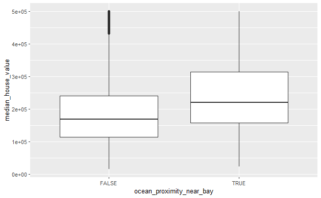

```r
housing_dummies %>%
  ggplot(aes(ocean_proximity_near_bay, median_house_value))+
  geom_boxplot()
```

```r
housing_dummies %>% summarise(cor = cor(ocean_proximity_near_bay, median_house_value))
```

| cor |
| --- |
| 0.157077 |

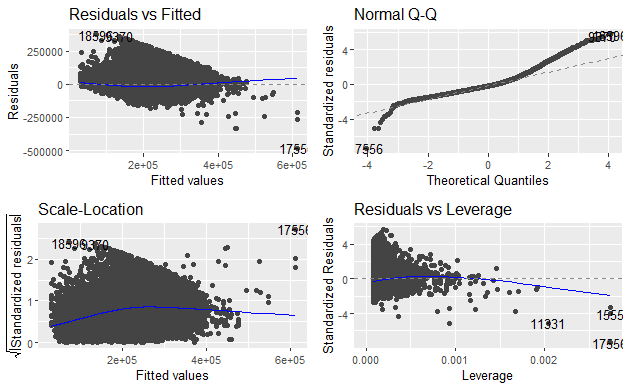

```r
#model using multiple linear regression
model_income_bay <- lm(median_house_value ~
                         median_income + ocean_prox_group,
                       housing_features)

#check diagnostics
autoplot(model_income_bay)# remember to ask about this, looks like there is a downward trend in the first plot.
```

```r
summary(model_income_bay)
```

```
Call:
lm(formula = median_house_value ~ median_income + ocean_prox_group,
    data = housing_features)

Residuals:
    Min      1Q  Median      3Q     Max
-481828  -42252  -11834   28057  376282

Coefficients:
                           Estimate Std. Error t value Pr(>|t|)
(Intercept)                 12086.5     1269.8   9.519   <2e-16 ***
median_income               34861.2      305.7 114.023   <2e-16 ***
ocean_prox_groupNear Water  78120.5     1019.7  76.608   <2e-16 ***
---
Signif. codes:  0 ‘***’ 0.001 ‘**’ 0.01 ‘*’ 0.05 ‘.’ 0.1 ‘ ’ 1

Residual standard error: 65710 on 19672 degrees of freedom
Multiple R-squared:  0.5478,    Adjusted R-squared:  0.5478
F-statistic: 1.192e+04 on 2 and 19672 DF,  p-value: < 2.2e-16
```